# Capstone: Who Gets a Callback? Racial Signals, Resume Quality, and Hiring Responses

A Binary Logistic Regression Analysis with Job-Level Random Intercepts

Author

Ching-Yi Cheng

Published

November 16, 2026

# Introduction

A callback is an early step in the hiring process. In the field experiment by Bertrand and Mullainathan (2004), researchers sent fictitious resumes to real job openings and assigned first names intended to signal different racial identities. This report estimates how callback probability differs between resumes with names intended to signal Black or White identity, before and after including resumes quality and city in the model.

**Research question.** How does the probability of an employer callback differ by the racial signal conveyed by the assigned first name, after accounting for resumes quality and city?

**Prediction.** Based on the original study, resumes with names intended to signal White identity are expected to receive callbacks more often than those with names intended to signal Black identity. This project is a reanalysis of the original experiment, so the prediction reflects prior knowledge of its findings.

# Workflow

# Overview of the Models

| Model | Fixed effects | Question |
| --- | --- | --- |
| M0 | Intercept | What is the baseline model before adding resume or city predictors? |
| M1 | Assigned name’s racial signal | Does including the racial signal improve fit? |
| M2 | M1 + resume quality | Does resume quality improve fit beyond the racial signal? |
| M3 | M2 + city | Does city improve fit beyond the resume characteristics? |

All models include a random intercept for job advertisement because several resume can be sent to the same opening. This term allows baseline callback odds to vary across advertisements. The binary outcome is modeled with a binomial distribution and a logit link.

# Dataset

Bertrand, Marianne, and Sendhil Mullainathan. 2004. “Are Emily and Greg More Employable Than Lakisha and Jamal? A Field Experiment on Labor Market Discrimination.” American Economic Review 94(4): 991–1013. https://doi.org/10.1257/0002828042002561

The [OpenIntro resume dataset](https://openintrostat.github.io/openintro/reference/resume.html) contains 4,870 applications sent to job openings in Boston and Chicago in 2001 and 2002. Each row represents one application. The data are distributed with the `openintro` R package.

| R variable | Role | Definition |
| --- | --- | --- |
| `received_callback` | Outcome | 1 = received a callback, 0 = did not receive a callback |
| `race` | Main predictor | Racial signal conveyed by the assigned first name. Black signal is the reference. |
| `resume_quality` | Predictor | Low or high resume quality, as coded in the dataset. Low is the reference. |
| `job_city` | Predictor | City in which the job was advertised. Boston is the reference. |
| `job_ad_id` | Grouping variable | Identifier for a job advertisement |

# Part 1 Prepare and explore the data

Install the packages once in the R console with `install.packages(c("openintro", "glmmTMB", "dplyr", "tidyr", "ggplot2", "gt", "DHARMa", "broom.mixed", "scales"))`.

```
Rows: 4,870
Columns: 5
$ received_callback <dbl> 0, 0, 0, 0, 0, 0, 0, 0, 0, 0, 0, 0, 0, 0, 0, 0, 0, 0…
$ race              <fct> White signal, White signal, Black signal, Black sign…
$ resume_quality    <fct> Low, High, Low, High, High, Low, High, High, Low, Hi…
$ job_city          <fct> Chicago, Chicago, Chicago, Chicago, Chicago, Chicago…
$ job_ad_id         <fct> 384, 384, 384, 384, 385, 386, 386, 385, 386, 386, 38…
```

```
   0    1
4478  392
```

```
Black signal White signal
        2435         2435
```

```
 Low High
2424 2446
```

```
 Boston Chicago
   2166    2704
```

After cleaning the data, I tabulated the callback outcome, the racial signal conveyed by the assigned name, resume quality, and job city. These counts show how applications are distributed across categories in the sample used for the model comparisons.

The analysis uses 4870 applications across 1323 job advertisements. Complete-case filtering excluded 0 applications. The overall observed callback rate was 8.0%. All four models use the same applications so their fit statistics can be compared directly.

## 1.Calculate observed callback rates

Table 1: Observed callback rates by racial signal and resume quality

| Name signal | Resume quality | Applications | Callbacks | Observed rate |
| --- | --- | --- | --- | --- |
| Black signal | Low | 1,212 | 75 | 6.2% |
| Black signal | High | 1,223 | 82 | 6.7% |
| White signal | Low | 1,212 | 103 | 8.5% |
| White signal | High | 1,223 | 132 | 10.8% |

These rates describe the applications as submitted. The table gives the denominator for each group and helps distinguish how often callbacks occurred from how many applications were submitted.

## 2.Examine how many applications each job advertisement received

| applications | job_advertisements |
| --- | --- |
| 2 | 211 |
| 4 | 1112 |

Figure 1: Applications sent per job advertisement

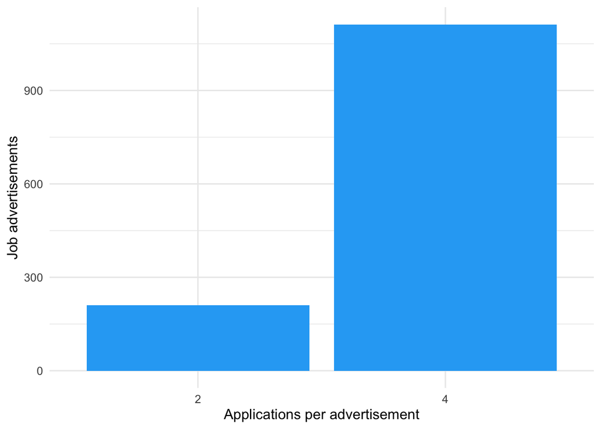

# Part 2. Fit the four models

The random intercept stays in every model, including M0. Each successive model adds one fixed predictor, which allows us to compare what that predictor contributes at that step. The model treats the racial-signal contrast as a common odds ratio across resume quality levels and cities.

```
 Family: binomial  ( logit )
Formula:          received_callback ~ 1 + (1 | job_ad_id)
Data: analysis_data

      AIC       BIC    logLik -2*log(L)  df.resid
   2020.7    2033.7   -1008.4    2016.7      4868

Random effects:

Conditional model:
 Groups    Name        Variance Std.Dev.
 job_ad_id (Intercept) 52.48    7.245
Number of obs: 4870, groups:  job_ad_id, 1323

Conditional model:
            Estimate Std. Error z value Pr(>|z|)
(Intercept)  -7.9162     0.3399  -23.29   <2e-16 ***
---
Signif. codes:  0 '***' 0.001 '**' 0.01 '*' 0.05 '.' 0.1 ' ' 1
```

```
 Family: binomial  ( logit )
Formula:          received_callback ~ race + (1 | job_ad_id)
Data: analysis_data

      AIC       BIC    logLik -2*log(L)  df.resid
   1980.8    2000.2    -987.4    1974.8      4867

Random effects:

Conditional model:
 Groups    Name        Variance Std.Dev.
 job_ad_id (Intercept) 57.23    7.565
Number of obs: 4870, groups:  job_ad_id, 1323

Conditional model:
                 Estimate Std. Error z value Pr(>|z|)
(Intercept)       -8.7522     0.3789 -23.097  < 2e-16 ***
raceWhite signal   1.1011     0.1758   6.263 3.78e-10 ***
---
Signif. codes:  0 '***' 0.001 '**' 0.01 '*' 0.05 '.' 0.1 ' ' 1
```

```
 Family: binomial  ( logit )
Formula:          received_callback ~ race + resume_quality + (1 | job_ad_id)
Data: analysis_data

      AIC       BIC    logLik -2*log(L)  df.resid
   1974.3    2000.2    -983.1    1966.3      4866

Random effects:

Conditional model:
 Groups    Name        Variance Std.Dev.
 job_ad_id (Intercept) 58.28    7.634
Number of obs: 4870, groups:  job_ad_id, 1323

Conditional model:
                   Estimate Std. Error z value Pr(>|z|)
(Intercept)         -9.0721     0.4016 -22.589  < 2e-16 ***
raceWhite signal     1.1109     0.1768   6.284  3.3e-10 ***
resume_qualityHigh   0.5023     0.1736   2.893  0.00381 **
---
Signif. codes:  0 '***' 0.001 '**' 0.01 '*' 0.05 '.' 0.1 ' ' 1
```

```
 Family: binomial  ( logit )
Formula:
received_callback ~ race + resume_quality + job_city + (1 | job_ad_id)
Data: analysis_data

      AIC       BIC    logLik -2*log(L)  df.resid
   1975.5    2007.9    -982.7    1965.5      4865

Random effects:

Conditional model:
 Groups    Name        Variance Std.Dev.
 job_ad_id (Intercept) 57.75    7.599
Number of obs: 4870, groups:  job_ad_id, 1323

Conditional model:
                   Estimate Std. Error z value Pr(>|z|)
(Intercept)         -8.8753     0.4502 -19.713  < 2e-16 ***
raceWhite signal     1.1097     0.1767   6.280 3.39e-10 ***
resume_qualityHigh   0.5019     0.1735   2.893  0.00382 **
job_cityChicago     -0.3268     0.3694  -0.885  0.37630
---
Signif. codes:  0 '***' 0.001 '**' 0.01 '*' 0.05 '.' 0.1 ' ' 1
```

## 1.Check optimizer convergence and whether the Hessian is positive definite

```
  M0   M1   M2   M3
TRUE TRUE TRUE TRUE
```

# Part 3. Compare model fit

Each likelihood-ratio test compares a model with the row immediately above it. AIC and BIC summarize fit with a penalty for additional parameters. The contribution of each predictor in the likelihood-ratio tests depends on the model sequence.

Table 2: Fit of the four nested mixed models

| Model | Term added | Log-likelihood | Parameters | AIC | BIC | LR χ² | df | p |
| --- | --- | --- | --- | --- | --- | --- | --- | --- |
| M0 | Baseline | −1,008.35 | 2 | 2,020.71 | 2,033.69 | — | — | — |
| M1 | Racial signal | −987.38 | 3 | 1,980.76 | 2,000.23 | 41.95 | 1 | < 0.001 |
| M2 | Resume quality | −983.13 | 4 | 1,974.25 | 2,000.22 | 8.50 | 1 | 0.00354 |
| M3 | City | −982.74 | 5 | 1,975.47 | 2,007.93 | 0.78 | 1 | 0.37762 |

The likelihood-ratio test for adding the name’s racial signal to the baseline model gave χ²(1) = 41.95 (p < .001). The lowest AIC was for M2 and the lowest BIC was for M2.

# Part 4. Select and diagnose the primary model

## 1.Model selection

M2 is the primary reporting model. Adding resume quality to M1 improved fit, χ²(1) = 8.50, *p* = 0.00354, and lowered AIC by 6.50. The BIC values for M1 and M2 were nearly identical. Adding city in M3 yielded little further improvement, χ²(1) = 0.78, *p* = 0.378, and increased both AIC and BIC. M2 estimates the callback contrast at the same resume quality and accounts for clustering within job advertisements. M3 checks how the estimated contrast changes after accounting for city.

## 2.Simulation-based diagnostics

The DHARMa Q–Q plot compares simulation-based residual quantiles with those expected under a uniform distribution. The plot on the right checks for residual patterns across fitted values. We also inspect residuals by racial signal and aggregate the simulated residuals at the job advertisement level.

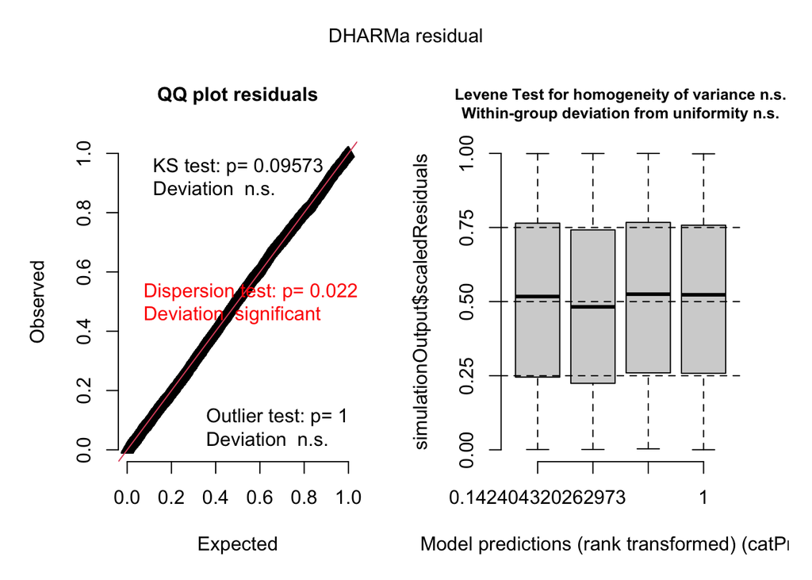

Figure 3: DHARMa Q–Q plot and residuals versus predicted values

## 3.Dispersion test

```
    DHARMa nonparametric dispersion test via sd of residuals fitted vs.
    simulated

data:  simulationOutput
dispersion = 1.0735, p-value = 0.022
alternative hypothesis: two.sided
```

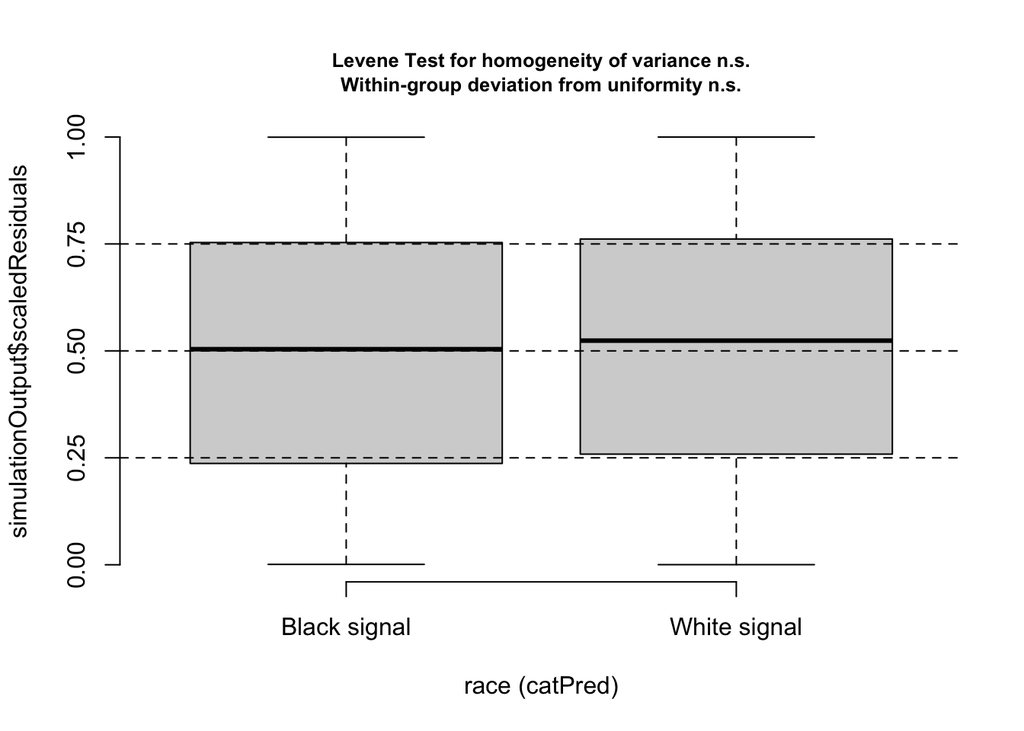

Figure 4: Simulation-based residuals by name signal

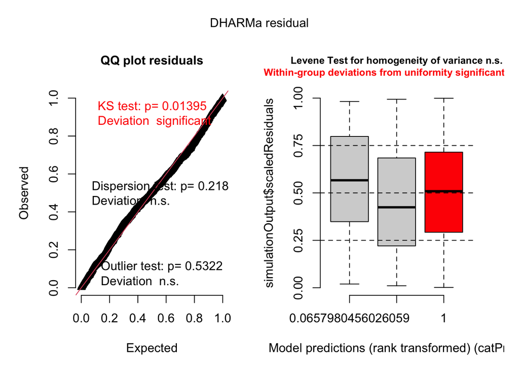

Figure 5: Simulation-based residuals aggregated by job advertisement

## 4.Summary of the Three Diagnostic Tests for Model 2

| Diagnostic | p |
| --- | --- |
| Application-level uniformity | 0.0957 |
| Application-level dispersion | 0.0220 |
| Advertisement-level uniformity | 0.0139 |

A systematic departure from the Q–Q diagonal, visible patterns by fitted value or group, or small diagnostic p-values warrant a closer look before interpreting M2. The plots and tests describe how the observed residual patterns compare with simulations from the fitted model.

# Part 5. Interpret the adjusted model

## 1.Adjusted odds ratios

The odds ratios compare applications at a common job advertisement random-intercept value, holding the other fixed predictor constant. An odds ratio above 1 indicates higher odds of a callback for the category listed first.

Table 3: Adjusted callback odds ratios from M2

| Comparison | Odds ratio | 95% CI lower | 95% CI upper |
| --- | --- | --- | --- |
| White signal vs. Black signal | 3.04 | 2.15 | 4.29 |
| High vs. low resume quality | 1.65 | 1.18 | 2.32 |

The adjusted odds ratio for a White-signaling name relative to a Black-signaling name was 3.04 (95% CI 2.15 to 4.29).

## 2.Sensitivity to including city

M2 and M3 use the same applications and the same job advertisement random intercept. Comparing their racial-signal odds ratios shows how much the estimate changes when city is included.

Table 4: Racial-signal odds ratios before and after accounting for city

| Model and adjustment variables | Odds ratio | 95% CI lower | 95% CI upper |
| --- | --- | --- | --- |
| M2: Resume quality | 3.04 | 2.15 | 4.29 |
| M3: Resume quality and city | 3.03 | 2.15 | 4.29 |

The estimated odds ratio was 3.04 in M2 and 3.03 after including city in M3.

# Part 6. Findings and limitations

In Model 2, for applications of the same resume quality sent to the same job opening, the estimated odds of receiving a callback were 3.04 times as high for applications with White-signaling names as for applications with Black-signaling names (95% CI [2.15, 4.29]). With city included in Model 3, the estimated odds ratio was 3.03. The estimates were similar across the two models. This difference in callback odds matters because an employer’s response can determine whether an applicant gets a chance to move forward in the hiring process.